# Parte-2-Moran_Geary

### Índice de Moran Local y detección de puntos atípicos

En el caso del problema provisto de temperaturas, el estadístico C de Geary con 0.5640437 nos está hablando de una correlación positiva. Es decir, a puntos de alta temperatura le corresponden puntos de alta temperatura a su alrededor, y lo mismo se espera con puntos de baja temperatura o temperatura media. Con el procedimiento de Moran Local procederemos a ver cuáles son los puntos atípicos cuya disimilaridad es sigficativa.

$$IML_{Si} = \frac{z(Si)- \bar{z}}{S^2} \sum_{j=1 j \neq i}^{n}w_{ij}(z(s_j)- \bar{z})$$

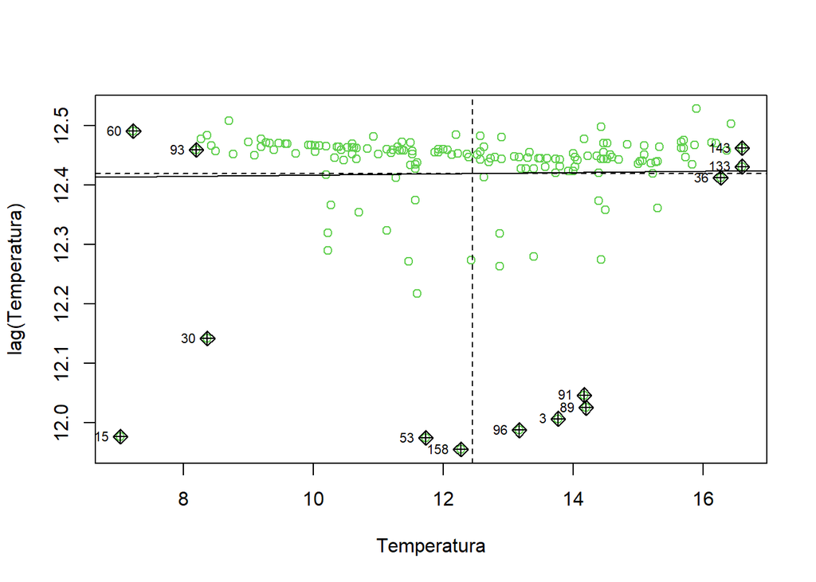

```r
M<-moran.plot(sp_geo_data$data,pesos,zero.policy=F,col=3, quiet=T,labels=T,xlab="Temperatura", ylab="lag(Temperatura)")
```

```r
View(M)

ML <- localmoran(sp_geo_data$data,pesos,alternative ="less")
IML<-printCoefmat(data.frame(ML,row.names=sp_geo_data$Casos),check.names=FALSE)
```

```
##                 Ii        E.Ii      Var.Ii        Z.Ii Pr.z...E.Ii..
##   [1,] -1.1804e-03 -4.5345e-03  1.7577e-04  2.5299e-01        0.5999
##   [2,] -7.0567e-03 -9.7861e-03  7.1469e-04  1.0210e-01        0.5407
##   [3,] -1.1701e-01 -2.1419e-03  2.2180e-03 -2.4389e+00        0.0074
##   [4,] -7.0275e-04 -2.4800e-04  7.9941e-06 -1.6084e-01        0.4361
##   [5,] -7.7578e-04 -3.8969e-03  1.5115e-04  2.5387e-01        0.6002
##   [6,]  6.2831e-04 -9.5105e-04  3.6998e-05  2.5965e-01        0.6024
##   [7,] -3.3167e-04 -1.4978e-04  9.4170e-07 -1.8743e-01        0.4257
##   [8,] -2.3846e-04 -2.5943e-03  1.6271e-05  5.8402e-01        0.7204
##   [9,]  7.1615e-02 -6.0774e-03  1.0119e-03  2.4423e+00        0.9927
##  [10,] -5.3059e-03 -2.2405e-03  4.2703e-05 -4.6910e-01        0.3195
##  [11,] -1.1459e-02 -1.9918e-02  5.0034e-04  3.7814e-01        0.6473
##  [12,] -6.6753e-03 -4.2214e-03  1.6368e-04 -1.9180e-01        0.4239
##  [13,] -3.5538e-04 -1.6692e-02  4.2069e-04  7.9649e-01        0.7871
##  [14,]  7.7718e-03 -6.9694e-03  3.6399e-04  7.7266e-01        0.7801
```

[output cut: 149 more lines]

```r
neg_Moran_Local <- subset(IML, Pr.z...E.Ii.. < 0.05 & Z.Ii < 0)
neg_IML <- as.numeric(rownames(neg_Moran_Local))

sp_data_final_clean <- sp_data_final[-c(neg_IML), ]
sp_geo_data_clean <- as.geodata(cbind(sp_data_final_clean$longitude,sp_data_final_clean$latitude,sp_data_final_clean$temp))
```

Eliminamos los desvíos negativos cuyo p-valor es menor al 0.05, de esta manera limpiamos a los datos de los valores atípicos con mayor disimilaridad.